# Teaching with Interactive Plots

## Interactive Plots

- **Comparative statics** is a central part of teaching economic models
- Typical approach: **Draw graphs for different sets of parameters**
  1. *what happens to the budget set when the price of a good changes*
  2. *what happens to a simulation when a std. changes*
- Problems: **Time consuming and clutters**
- Enter: **Interactive plots** using Python and Jupyter Notebooks running *in the cloud* (no installation)

### Micro: Budgetset

```python
budgetset.exogenous()
```

### Micro: Utility Maximization - Cobb-Douglas

```python
utilitymax.cobb_douglas()
```

### Micro: Utility Maximization - Qausi-Linear

$$u(x_1,x_2) = \alpha\sqrt(x_1) + \beta x_2$$

```python
utilitymax.quasi_linear_case_2()
```

### Macro: Solow Model

Consider the Solow-model summarized by: $ k_{t+1} - k_t = s k_t^\alpha - \delta k_t $

```python
solow.simulate()
```

### Macro: AS-AD model

Consider the AS-AD model:

$$ \begin{eqnarray*} \hat{y}_{t} &=& b\hat{y}_{t-1}+\beta(z_{t}-z_{t-1})-a\beta s_{t}+a\beta\phi s_{t-1} \\ \hat{\pi}_{t} &=& b\hat{\pi}_{t-1}+\beta\gamma z_{t}-\beta\phi\gamma z_{t}+\beta s_{t}-\beta\phi s_{t-1} \\ z_{t} &=& \delta z_{t-1}+x_{t}, x_{t} \sim N(0,\sigma_x^2) \\ s_{t} &=& \omega s_{t-1}+c_{t}, c_{t} \sim N(0,\sigma_c^2) \\ b &=& \frac{1+a\phi\gamma}{1+a\gamma} \\ \beta &=& \frac{1}{1+a\gamma} \end{eqnarray*} $$

```python
asad.simulate()
```

### Statistics: Stochastic Variable

```python
stochasticvar.dice()
```

### Statistics: Conditional Probability

```python
conditional_probability.bivariate_normal_standard()
```

### Descriptive Economics: DST

```python
dst.plot() # load online data directly from Statistikbanken.dk
```

## Code Behind

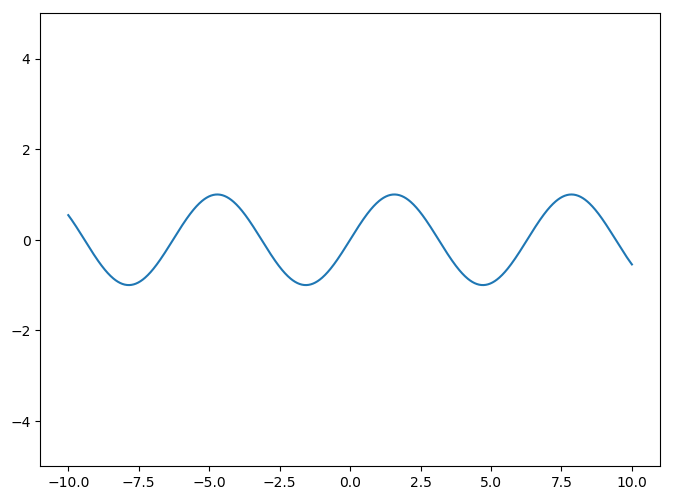

```python
# standard Python function for plotting
def f(α):
    x = np.linspace(-10, 10, num=1000)
    y = np.sin(α*x)
    plt.figure(figsize=(8,6),dpi=100)
    plt.plot(x,y)
    plt.ylim(-5, 5)
    plt.show()

α = 1
f(α)
```

```python
# additional lines of code
interactive_plot = widgets.interactive(f, α=(-2.0, 2.0))
interactive_plot
```

### Dropbox menu

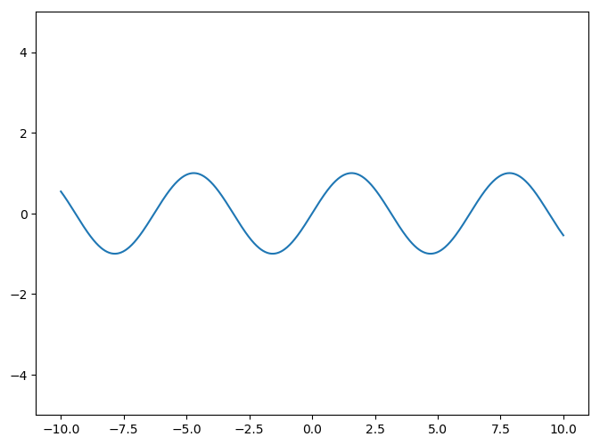

```python
# standard Python function for plotting
def h(g,α):
    x = np.linspace(-10, 10, num=1000)
    if g == 'sin':
        y = np.sin(α*x)
    elif g == 'cos':
        y = np.cos(α*x)
    plt.figure(figsize=(8,6),dpi=100)
    plt.plot(x,y)
    plt.ylim(-5, 5)
    plt.show()

α = 1
g = 'sin'
h(g,α)
```

```python
# additional lines of code
interactive_plot = widgets.interactive(h, g=['sin','cos'], α=(-2.0, 2.0))
interactive_plot
```

## No Installation Required!

- **Now:** I am running it on my laptop
- **If Python not installed:** run it online on mybinder.org:
  1. Direct to utility maximization example: [goo.gl/yRU9UV](https://goo.gl/GQUJho)
  2. Folder with all examples: goo.gl/GQUJho
- **Code** online at GitHub: github.com/JeppeDruedahl/NumEcon

## Student Labour

- New course spring 2019: **Introduction to programming and numerical analysis**
- The **students will learn**
  1. Solving simple economic models from the bachelor courses
  2. Producing plots of their solutions
  3. Making these plots interactive
- **Exam**: Model analysis project with "free" choice of topic
- **You need an interactive plot for your course?** This could be a student exam project